# Feature Engineering

Author

Marina Muradian - Insper

```r
library(tidyverse)
library(ggthemes)
library(lubridate)
library(RColorBrewer)
load("training.RData")
```

## Viagens da Estação Clark/Lake (s_40380)

Variável **QUANTITATIVA**

Utilizaremos o boxplot para visualizar sua distribuição

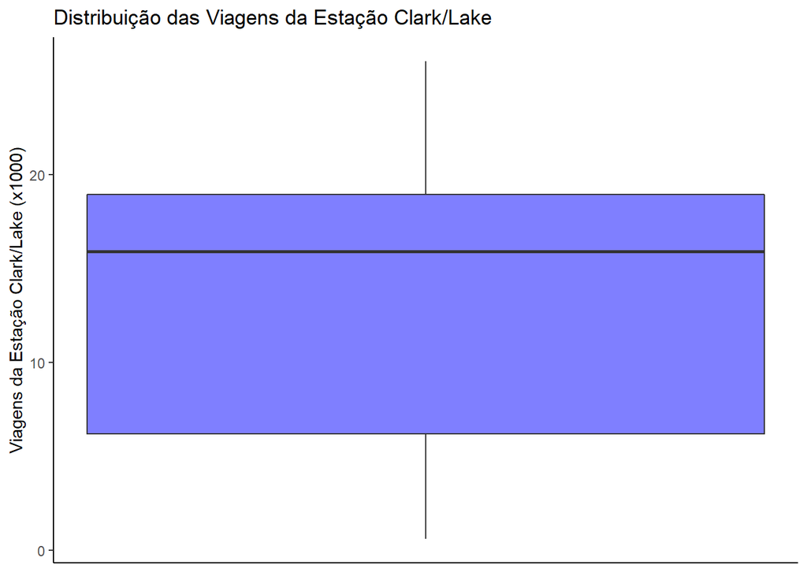

```r
training %>%
  ggplot(aes(y=s_40380))+
  geom_boxplot(fill = "blue", alpha = 0.5) +
  theme(axis.ticks.x = element_blank(),
        axis.text.x = element_blank(),
        panel.background = element_blank(),
        axis.line.y = element_line(),
        axis.line.x = element_line()) +
  labs(y = "Viagens da Estação Clark/Lake (x1000)",
       title = "Distribuição das Viagens da Estação Clark/Lake")
```

A distribuição parece simétrica?

Para visualizar melhor a distribuição, vamos utilizar um histograma alisado:

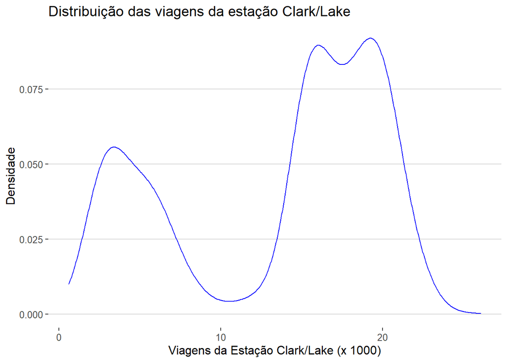

```r
training %>%
ggplot(aes(x = s_40380)) +
  geom_density(color = "blue") +
  theme_hc()+
  labs(y = "Densidade",
       title = "Distribuição das viagens da estação Clark/Lake",
       x = "Viagens da Estação Clark/Lake (x 1000)")
```

Verificamos que a distribuição é bimodal, ou seja, temos dois “picos” de densidade. O que pode estar relacionado com isso?

## Dia da semana importa?

Vamos criar uma variável que indique se o dia é final de semana ou não e, em seguida visualizar o histograma alisado anterior dividido por dia da semana e final de semana. Neste caso, a nova variável criada é **QUALITATITVA** e será representada pela cor no gráfico:

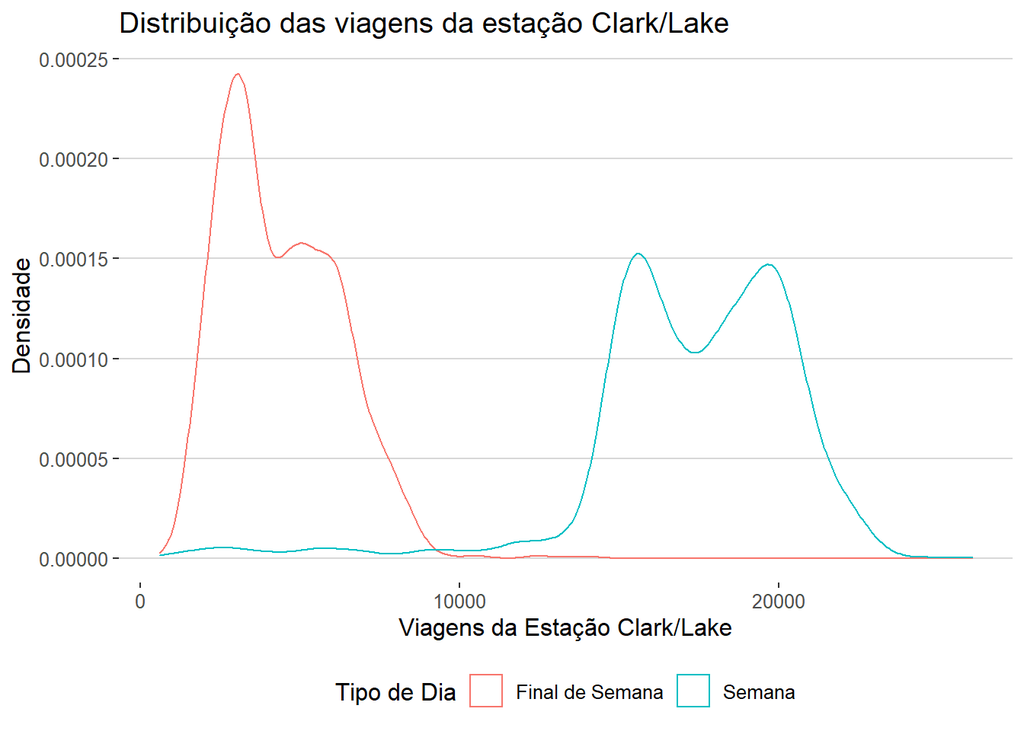

```r
training %>%
  mutate(tipo_dia = ifelse(dow %in% c("Sat", "Sun"), "Final de Semana", "Semana")) %>%
  ggplot(aes(x = s_40380*1000, col = tipo_dia))+
  geom_density() +
  theme_hc()+
  labs(y = "Densidade",
       title = "Distribuição das viagens da estação Clark/Lake",
       x = "Viagens da Estação Clark/Lake",
       color = "Tipo de Dia")
```

## Há mais alguma sazonalidade importante?

Vamos analisar se há relação entre o número de viagens na semana corrente (s_40380) e o número de viagens 14 dias antes (l14_40380), mantendo a distinção de final de semana e dia de semana.

Como ambas as variáveis são **QUANTITATIVAS**, podemos utilizar um gráfico de dispersão, com a cor representando a variável **QUALITATIVA** que representa o tipo de dia:

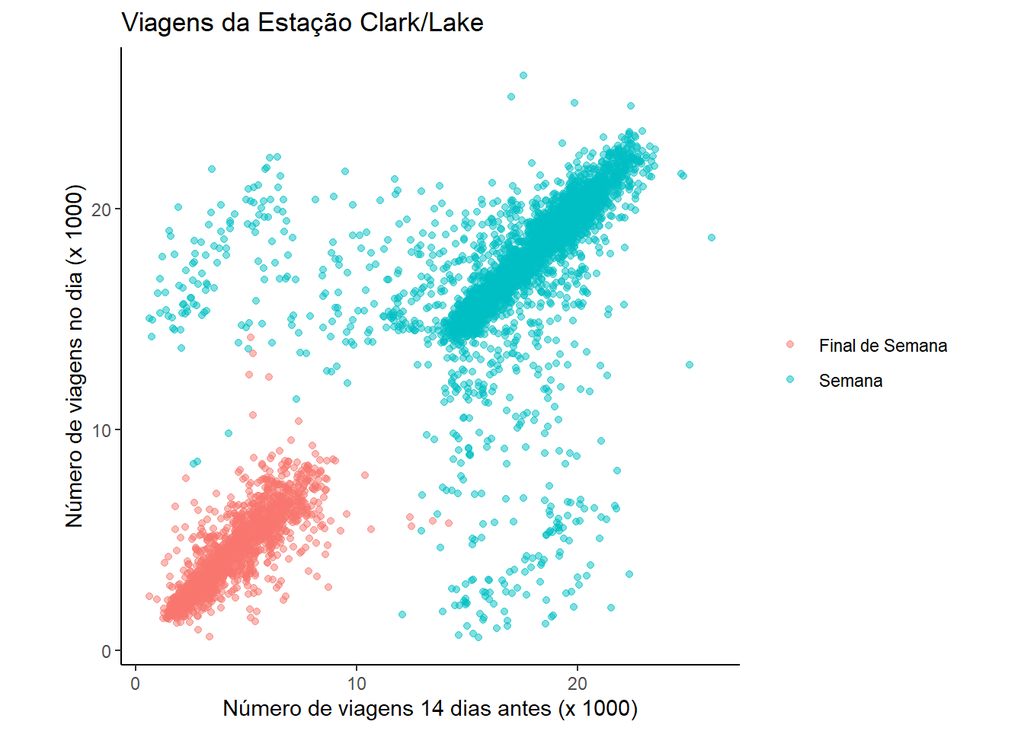

```r
training %>%
  mutate(tipo_dia = ifelse(dow %in% c("Sat", "Sun"), "Final de Semana", "Semana")) %>%
  ggplot(aes(l14_40380,s_40380, color = tipo_dia)) +
  geom_point(alpha=0.5)  +
  labs(y = "Número de viagens no dia (x 1000)",
       x = "Número de viagens 14 dias antes (x 1000)",
       title = "Viagens da Estação Clark/Lake") +
  theme(legend.title=element_blank(),
        panel.background = element_blank(),
        axis.line = element_line(),
        legend.key=element_rect(fill="white")) +
  coord_equal()
```

O que podem ser esses outliers?

Vamos verificar se podem ser feriados:

```r
feriados <-
  c("USNewYearsDay", "Jan02_Mon_Fri", "USMLKingsBirthday",
    "USPresidentsDay", "USMemorialDay", "USIndependenceDay",
    "Jul03_Mon_Fri", "Jul05_Mon_Fri", "USLaborDay", "USThanksgivingDay",
    "Day_after_Thx", "ChristmasEve", "USChristmasDay", "Dec26_wkday",
    "Dec31_Mon_Fri")

# feriados na data atual
training <- training %>%
  select(date, feriados) %>%
  pivot_longer(feriados,
               names_to = "feriado",
               values_to = "valor") %>%
  group_by(date) %>%
  summarize(indicador_feriado = max(valor)) %>%
  ungroup() %>%
  inner_join(training, by = "date")
```

```
Note: Using an external vector in selections is ambiguous.
i Use `all_of(feriados)` instead of `feriados` to silence this message.
i See <https://tidyselect.r-lib.org/reference/faq-external-vector.html>.
```

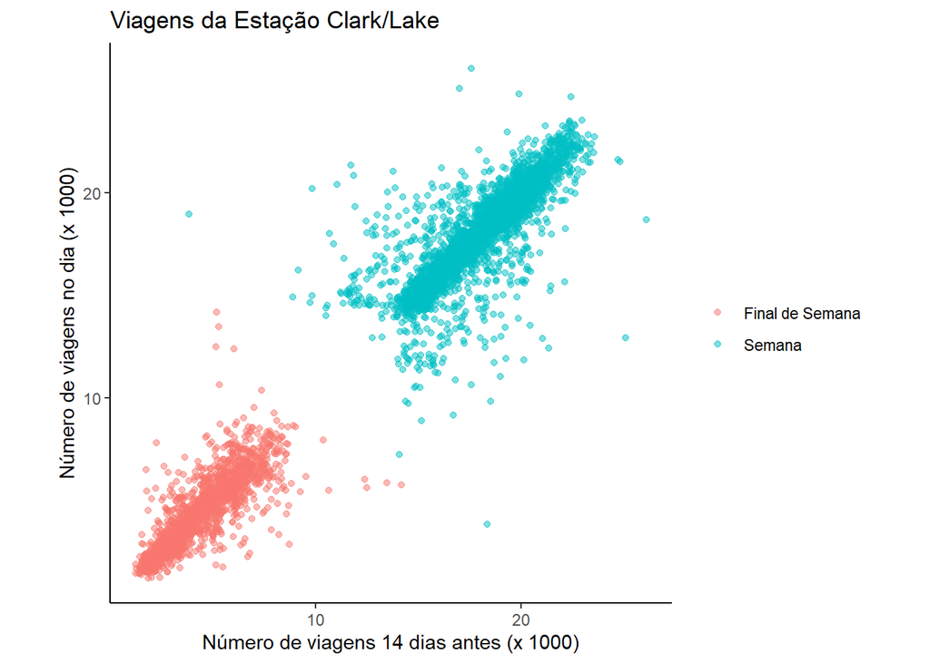

```r
# feriado no lag de 14 dias

training <- training %>%
  mutate(date_l14 = date + days(14))

training <- training %>%
  select(date = date_l14, feriados) %>%
  pivot_longer(feriados,
               names_to = "feriado",
               values_to = "valor") %>%
  group_by(date) %>%
  summarize(indicador_feriado_l14 = max(valor)) %>%
  ungroup() %>%
  inner_join(training, by = "date")

training %>%
  mutate(tipo_dia = ifelse(dow %in% c("Sat", "Sun"), "Final de Semana", "Semana")) %>%
  filter(indicador_feriado == 0 & indicador_feriado_l14 == 0) %>%
  ggplot(aes(l14_40380,s_40380, color = tipo_dia)) +
  geom_point(alpha=0.5)  +
  labs(y = "Número de viagens no dia (x 1000)",
       x = "Número de viagens 14 dias antes (x 1000)",
       title = "Viagens da Estação Clark/Lake") +
  theme(legend.title=element_blank(),
        panel.background = element_blank(),
        axis.line = element_line(),
        legend.key=element_rect(fill="white")) +
  coord_equal()
```

## Os dados seguem alguma tendência?

Vamos olhar para as viagens de trem ao longo do tempo (excluindo feriados):

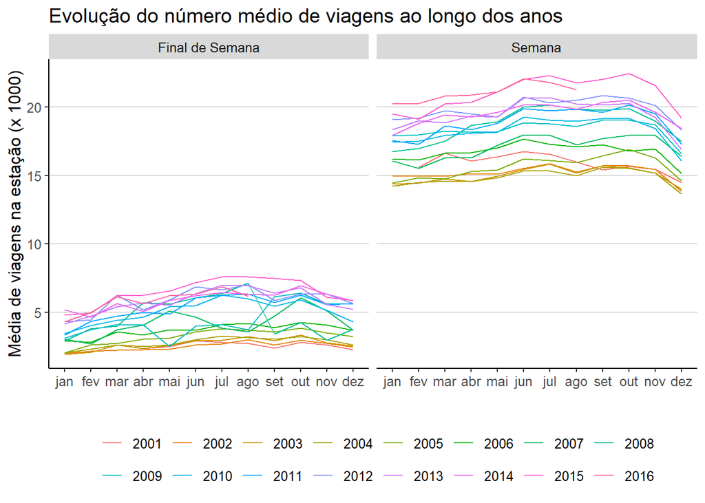

```r
training %>%
  filter(indicador_feriado_l14 == 0 , indicador_feriado == 0) %>%
  mutate(tipo_dia = ifelse(dow %in% c("Sat", "Sun"), "Final de Semana", "Semana"),
         year = factor(year),
         mes = month(date, label = TRUE, abbr = TRUE)) %>%
  group_by(year, mes, tipo_dia) %>%
  summarise(media_viagens = mean(s_40380, na.rm = TRUE)) %>% ggplot(aes(x = mes, y = media_viagens, group = year, col = year))+
  geom_line()+
  facet_wrap(~tipo_dia, ncol = 2)+
  labs(x = "",
       y = "Média de viagens na estação (x 1000)",
       title = "Evolução do número médio de viagens ao longo dos anos",
       col = "")+
  guides(col = guide_legend(nrow = 2, byrow = TRUE))+
  theme(legend.position = "bottom",
        axis.line = element_line())+
  theme_hc()
```

Percebemos que 2008 tem um comportamento diferente pelo pico de viagens no verão em finais de semana.

Investigando o que aconteceu em 2008 utilizando a evolução do preço da gasolina:

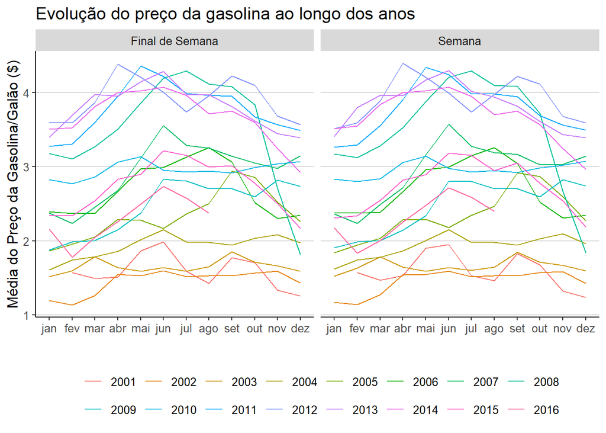

```r
training %>%
  filter(indicador_feriado_l14 == 0 , indicador_feriado == 0) %>%
  mutate(tipo_dia = ifelse(dow %in% c("Sat", "Sun"), "Final de Semana", "Semana"),
         year = factor(year),
         mes = month(date, label = TRUE, abbr = TRUE)) %>%
  group_by(year, mes, tipo_dia) %>%
  summarise(media_preco = mean(l14_gas_price, na.rm = TRUE)) %>% ggplot(aes(x = mes, y = media_preco, group = year, col = year))+
  geom_line()+
  facet_wrap(~tipo_dia, ncol = 2)+
  labs(x = "",
       y = "Média do Preço da Gasolina/Galão ($)",
       title = "Evolução do preço da gasolina ao longo dos anos",
       col = "")+
  guides(col = guide_legend(nrow = 2, byrow = TRUE))+
  theme(legend.position = "bottom",
        axis.line = element_line())+
  theme_hc()
```

Preços sobem no verão de 2008, mesma ocasião em que o número de viagens aumenta:

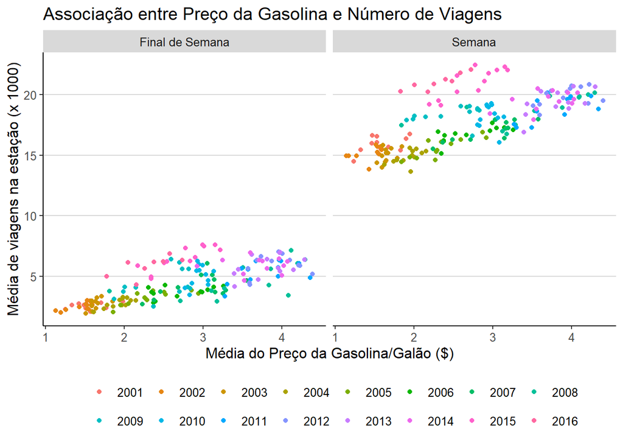

```r
training %>%
  filter(indicador_feriado_l14 == 0 , indicador_feriado == 0) %>%
  mutate(tipo_dia = ifelse(dow %in% c("Sat", "Sun"), "Final de Semana", "Semana"),
         year = factor(year),
         mes = month(date, label = TRUE, abbr = TRUE)) %>%
  group_by(year, mes, tipo_dia) %>%
  summarise(media_viagens = mean(s_40380, na.rm = TRUE),
            media_preco = mean(l14_gas_price, na.rm = TRUE)) %>%
  ggplot(aes(x = media_preco, y = media_viagens, group = year, col = year))+
  geom_point()+
  facet_wrap(~tipo_dia, ncol = 2)+
  labs(x = "Média do Preço da Gasolina/Galão ($)",
       y = "Média de viagens na estação (x 1000)",
       title = "Associação entre Preço da Gasolina e Número de Viagens",
       col = "")+
  guides(col = guide_legend(nrow = 2, byrow = TRUE))+
  theme(legend.position = "bottom",
        axis.line = element_line())+
  theme_hc()
```